# Part I - DIABETES DATA EXPLORATION

## by Eric Anku

- Introduction
- Univariate exploration
- Bivariate exploration
- Multivariate exploration
- Conclusions

## Introduction

This documentation explores a diabetes dataset of females at least 21 years and older. Females are of Pima Indian Heritage. There are 768 observation with 9 variables in the dataset. Dataset can be found [here](https://www.kaggle.com/datasets/mathchi/diabetes-data-set).

## Preliminary Wrangling

```python
import warnings
warnings.filterwarnings('ignore')

# import all packages
import numpy as np
import pandas as pd
import matplotlib.pyplot as plt
import seaborn as sns
import zipfile
```

```python
# Unzip dataset file
with zipfile.ZipFile("data/diabetes.zip", "r") as file:
    file.extractall()
```

```python
# Import dataset
diabetes = pd.read_csv("diabetes.csv")
```

```python
# First five rows of the diabetes data
diabetes.head()
```

|  | Pregnancies | Glucose | BloodPressure | SkinThickness | Insulin | BMI | DiabetesPedigreeFunction | Age | Outcome |
| --- | --- | --- | --- | --- | --- | --- | --- | --- | --- |
| 0 | 6 | 148 | 72 | 35 | 0 | 33.6 | 0.627 | 50 | 1 |
| 1 | 1 | 85 | 66 | 29 | 0 | 26.6 | 0.351 | 31 | 0 |
| 2 | 8 | 183 | 64 | 0 | 0 | 23.3 | 0.672 | 32 | 1 |
| 3 | 1 | 89 | 66 | 23 | 94 | 28.1 | 0.167 | 21 | 0 |
| 4 | 0 | 137 | 40 | 35 | 168 | 43.1 | 2.288 | 33 | 1 |

```python
# Concise summary of dataset
diabetes.info()
```

```
<class 'pandas.core.frame.DataFrame'>
RangeIndex: 768 entries, 0 to 767
Data columns (total 9 columns):
 #   Column                    Non-Null Count  Dtype
---  ------                    --------------  -----
 0   Pregnancies               768 non-null    int64
 1   Glucose                   768 non-null    int64
 2   BloodPressure             768 non-null    int64
 3   SkinThickness             768 non-null    int64
 4   Insulin                   768 non-null    int64
 5   BMI                       768 non-null    float64
 6   DiabetesPedigreeFunction  768 non-null    float64
 7   Age                       768 non-null    int64
 8   Outcome                   768 non-null    int64
dtypes: float64(2), int64(7)
memory usage: 54.1 KB
```

- There are nine variables and 768 participants in the dataset. There are no missing values.
- Data type for `Outcome` is int rather than object.

```python
# Dimensions of dataset
diabetes.shape
```

```
(768, 9)
```

- The above information shows there are 768 observations and nine variables in the dataset.

```python
# Summary statistics of numeric variables
diabetes.describe()
```

|  | Pregnancies | Glucose | BloodPressure | SkinThickness | Insulin | BMI | DiabetesPedigreeFunction | Age | Outcome |
| --- | --- | --- | --- | --- | --- | --- | --- | --- | --- |
| count | 768.000000 | 768.000000 | 768.000000 | 768.000000 | 768.000000 | 768.000000 | 768.000000 | 768.000000 | 768.000000 |
| mean | 3.845052 | 120.894531 | 69.105469 | 20.536458 | 79.799479 | 31.992578 | 0.471876 | 33.240885 | 0.348958 |
| std | 3.369578 | 31.972618 | 19.355807 | 15.952218 | 115.244002 | 7.884160 | 0.331329 | 11.760232 | 0.476951 |
| min | 0.000000 | 0.000000 | 0.000000 | 0.000000 | 0.000000 | 0.000000 | 0.078000 | 21.000000 | 0.000000 |
| 25% | 1.000000 | 99.000000 | 62.000000 | 0.000000 | 0.000000 | 27.300000 | 0.243750 | 24.000000 | 0.000000 |
| 50% | 3.000000 | 117.000000 | 72.000000 | 23.000000 | 30.500000 | 32.000000 | 0.372500 | 29.000000 | 0.000000 |
| 75% | 6.000000 | 140.250000 | 80.000000 | 32.000000 | 127.250000 | 36.600000 | 0.626250 | 41.000000 | 1.000000 |
| max | 17.000000 | 199.000000 | 122.000000 | 99.000000 | 846.000000 | 67.100000 | 2.420000 | 81.000000 | 1.000000 |

- The minimum values for `Glucose`, `Blood Pressure`, `SkinThickness`, `Insulin`, `BMI` are unlikely as these values do not have a meaningful 0.

### Clean dataset

- Convert datatype `Outcome` to object datatype.
- Remove 0 values from `Glucose`, `BloodPressure`, `SkinThickness`, `Insulin`, `BMI` as these values are unlikely measurements and may skew the distribution of the variables.

```python
# Convert Outcome into an object datatype
diabetes["Outcome"] = diabetes["Outcome"].astype("object")
```

```python
# Assess to check conversion
diabetes["Outcome"].dtype
```

```
dtype('O')
```

Outcome was converted to an object data where 0 is No diabetes and 1 is Presence of diabetes

```python
# Replace 0 with NA in columns with unlikely values

## Columns to mutate in a list
columns_replace = ["Glucose", "BloodPressure", "SkinThickness", "Insulin", "BMI"]

## Replace 0 with NA
diabetes[columns_replace] = diabetes[columns_replace].replace(0, np.nan)
```

```python
# Assess values to see changes made with replacement
diabetes.describe()
```

|  | Pregnancies | Glucose | BloodPressure | SkinThickness | Insulin | BMI | DiabetesPedigreeFunction | Age |
| --- | --- | --- | --- | --- | --- | --- | --- | --- |
| count | 768.000000 | 763.000000 | 733.000000 | 541.000000 | 394.000000 | 757.000000 | 768.000000 | 768.000000 |
| mean | 3.845052 | 121.686763 | 72.405184 | 29.153420 | 155.548223 | 32.457464 | 0.471876 | 33.240885 |
| std | 3.369578 | 30.535641 | 12.382158 | 10.476982 | 118.775855 | 6.924988 | 0.331329 | 11.760232 |
| min | 0.000000 | 44.000000 | 24.000000 | 7.000000 | 14.000000 | 18.200000 | 0.078000 | 21.000000 |
| 25% | 1.000000 | 99.000000 | 64.000000 | 22.000000 | 76.250000 | 27.500000 | 0.243750 | 24.000000 |
| 50% | 3.000000 | 117.000000 | 72.000000 | 29.000000 | 125.000000 | 32.300000 | 0.372500 | 29.000000 |
| 75% | 6.000000 | 141.000000 | 80.000000 | 36.000000 | 190.000000 | 36.600000 | 0.626250 | 41.000000 |
| max | 17.000000 | 199.000000 | 122.000000 | 99.000000 | 846.000000 | 67.100000 | 2.420000 | 81.000000 |

- The above dataset now shows meaningful minimum values for `Glucose`, `Blood Pressure`, `SkinThickness`, `Insulin`, `BMI`. This has also influenced the average estimations and the deviations around them.

### What is the structure of your dataset?

There are 768 females in the dataset with 9 features (`Pregnancies`, `Glucose`, `BloodPressure`, `SkinThickness`, `Insulin`, `BMI`, `DiabetesPedigreeFunction`, `Age`, and `Outcome`). All features are numeric except Outcome which is a categorical variable where 0 means no diabetes and 1 meaning diabetes.

`Pregnancies`: Number of times a woman was pregnant.

`Glucose`: Plasma glucoes concentration after 2 hours on an oral glucose tolerance test (no unit was specified).

`Blood pressure`: Diastolic blood pressure measured in mmHg.

`SkinThickness`: Triceps skin fold thickness measured in mm.

`Insulin`: Serum insulin after 2 hours measured in mu U/ml.

`BMI`: Body mass index measured in kg/m^2.

`DiabetesPedigreeFunction`: Diabetes pedigree function which is a function that score the likelihood of having diabetes based on the family history of the participant.

`Age`: Age of participant in years.

`Outcome`: Represented whether participant had diabetes (0: No, 1: Yes).

### What is/are the main feature(s) of interest in your dataset?

I am interested in examining the relationship between the features (Pregnancies, Glucose, BloodPressure, SkinThickness, Insulin, BMI, DiabetesPedigreeFunction, Age) and Outcome.

### What features in the dataset do you think will help support your investigation into your feature(s) of interest?

I hypothesize that features such as Number of pregnancies, Glucose, SkinThickness, Insulin, BMI, DiabetesPedigreeFunction and Age will be strongly associated with the outcome of diabetes.

## Univariate Exploration

```python
# Histogram function

def histogram(x):
    plt.hist(x, bins = np.arange(0, x.max()+5,5))

# Function to create histogram distributions, log transformations and box plot

def histogram_distributions(x):
    ## Figure size
    plt.figure(figsize=[30,5])

    ## Subplot 1
    plt.subplot(1,4,1)
    histogram(x)


    ## Subplot 2
    plt.subplot(1,4,2)
    sns.distplot(x);


    ## Subplot 3
    plt.subplot(1,4,3)
    sns.distplot(x);
    plt.xscale("log")

    ## Subplot 4
    plt.subplot(1,4,4)
    x.plot(kind="box");
```

### Q1. What is the distribution of pregnancies among study participants?

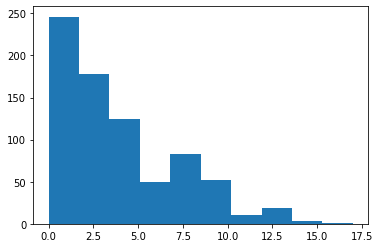

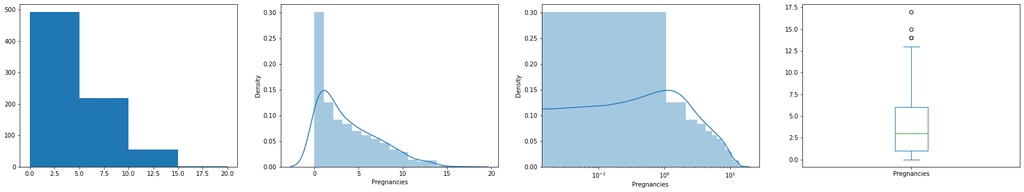

```python
# Univariate exploration of Pregnancies

## Distribution of pregnancies
plt.hist(diabetes["Pregnancies"]);

histogram_distributions(diabetes["Pregnancies"]);
```

**Observation**: The distribution of pregnancies is skewed to the right with majority of women having 1-5 pregnancies and a few having above 15 pregnancies. Log transformation in the second distribution plot did not deal with the skewness of the variable. The boxplot depicts outliers with the number of pregnancies. The outliers also contribute to the observed skewness in the feature.

### Q2: What is the distribution of plasma glucose concentration among study participants 2 hours after an oral glucose tolerance test (OGTT)?

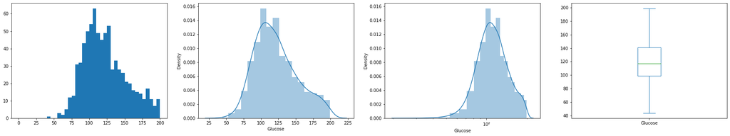

```python
# Univariate exploration of Glucose
histogram_distributions(diabetes["Glucose"])
```

**Observation**: The distribution of glucose concentration is skewed to the right. Outliers in blood glucose concentration are below 50 with majority of readings between 75 and 150. Adding a log transformation has minimised the skewness and makes the distribution appear normal. In contrast to earlier observation made from the distribution plot, the boxplot distribution does not indicate the presence of an outlier in the distribution of plasma glucose concentration.

### Q3: What is the distribution of blood pressure among study participants?

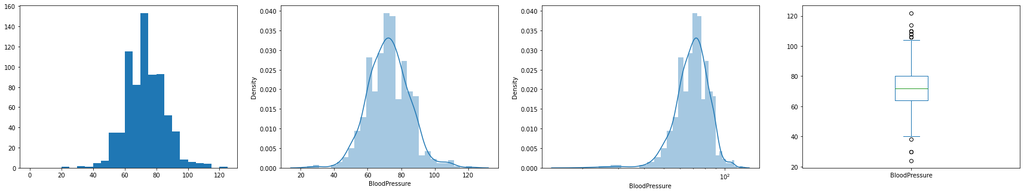

```python
# Univariate exploration of BloodPressure

histogram_distributions(diabetes["BloodPressure"]);
```

**Observation**: Blood pressure ranges from 20 mmHg to above 120 mmHg. Outliers are observed in the blood pressure feature below 40 mmHg and above 100 mmHg. The distribution looks normal but this may have been impacted by the outliers in the feature.

### Q4: What is the distribution of triceps skinfold thickness among study participants?

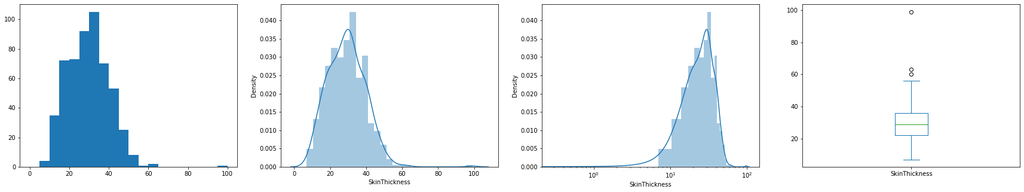

```python
# Univariate exploration of SkinThickness

histogram_distributions(diabetes["SkinThickness"]);
```

**Observation**: The distribution of skinfold thickness appears right skewed with a significant outlier with a value of 100. Values range from above 5 to below 65. The outliers present is contributing to the skewness observed.

### Q5: What is the distribution of insulin among study participants?

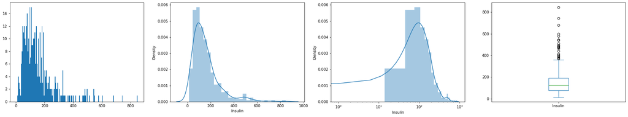

```python
# Univariate exploration of Insulin

histogram_distributions(diabetes["Insulin"]);
```

**Observation**: Insulin measured is significantly skewed to the right. Values range from greater than 0 to about 400. However, outliers present are significant and contributing to the observed skewness. Log transformation has minimised skewness as observed in the second distribution plot.

### Q6: What is the distribution of BMI among study participants?

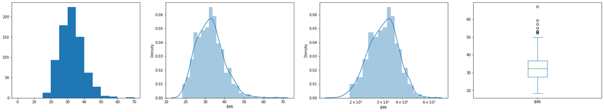

```python
# Univariate exploration of BMI

histogram_distributions(diabetes["BMI"]);
```

**Observation**: The distribution of BMI in the sample is right skewed with outliers present with values above 50 kgm-2. Log transformation has minimised skewness observed.

### Q7: What is the distribution of diabetes pedigree function among study participants?

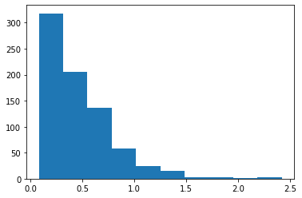

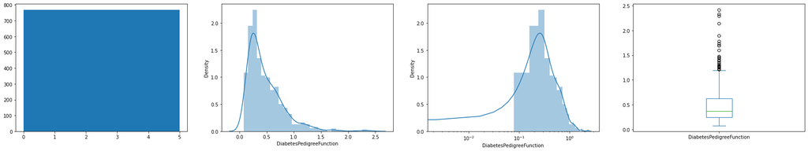

```python
# Univariate exploration of DiabetesPedigreeFunction

## Histogram to show distribution appropriately aside visualisation displayed from histogram_distributions function
plt.hist(diabetes["DiabetesPedigreeFunction"]);


## Distributions and assessing outliers in `DiabetesPedigreeFunction`

histogram_distributions(diabetes["DiabetesPedigreeFunction"]);
```

**Observation**: Diabetes pedigree function is skewed to the right and log transformation has minised the skewness. Outliers present in the feature are also contributing to the observed skewness.

### Q8: What is the distribution of age among study participants?

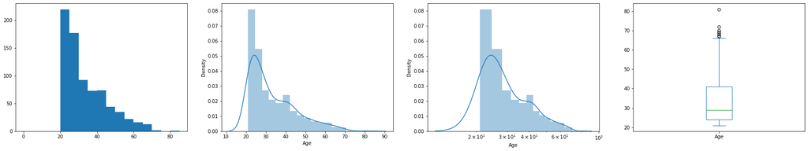

```python
# Univariate exploration of Age

histogram_distributions(diabetes["Age"]);
```

**Observation**: Majority of participants are between the ages of 20 to 40 with a few participants above 80. The distribution of age in the sample is right skewed with outliers present in the distribution.

### Q9: How many participants have diabetes or no diabetes?

[output not shown]

[figure not shown]

```python
# Univariate plot of Outcome
plt.figure(figsize = [15,5])

# Bar chart with absolute counts
plt.subplot(1,2,1)
base_color = sns.color_palette()[0]
sns.countplot(data = diabetes, x= "Outcome", color = base_color);

# Bar charts with proportions
plt.subplot(1,2,2)
diabetes["Outcome"].value_counts(normalize = True).plot(kind = "bar");
diabetes["Outcome"].value_counts(normalize = True)
```

**Observation**: Majority of participants in the study do not have diabetes.

### Remove outliers identified in previous visualisations

- Outliers are removed as they have a potential of introducing bias and they can influence result estimates. They also tend to skew the distribution of features.

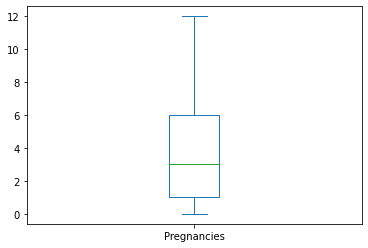

```python
# Pregnancies

# Masking for pregnancy feature with outliers
pregnancy_outlier = diabetes["Pregnancies"] < 12.5

# Remove outliers from pregnancy feature
diabetes = diabetes[pregnancy_outlier]

# Visualise to assess if outliers are present
diabetes["Pregnancies"].plot(kind="box");
```

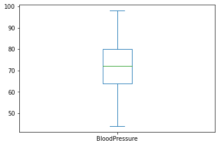

```python
# BloodPressure

blood_pressure_outlier = diabetes["BloodPressure"] < 100
blood_pressure_outlier2 = diabetes["BloodPressure"] > 40

# Remove outliers from blood pressure feature
diabetes = diabetes[blood_pressure_outlier]
diabetes = diabetes[blood_pressure_outlier2]

# Visual inspection
diabetes["BloodPressure"].plot(kind="box");
```

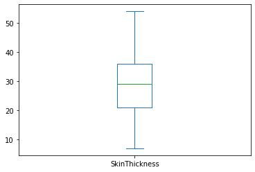

```python
# Triceps Skinfold

skinthickness_outlier = diabetes["SkinThickness"] < 55

# Remove outliers from skin thickness feature
diabetes = diabetes[skinthickness_outlier]

#Visual inspection
diabetes["SkinThickness"].plot(kind="box");
```

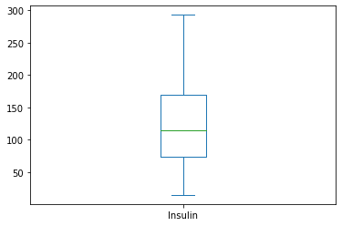

```python
# Insulin


# Remove outliers from insulin feature
insulin_outlier = diabetes["Insulin"] < 300

diabetes = diabetes[insulin_outlier]

# Visual inspection
diabetes["Insulin"].plot(kind="box");
```

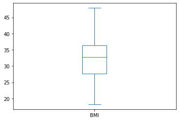

```python
# BMI

# Remove outliers from BMI feature
bmi_outlier = diabetes["BMI"] < 49

diabetes = diabetes[bmi_outlier]

# Visual inspection
diabetes["BMI"].plot(kind="box");
```

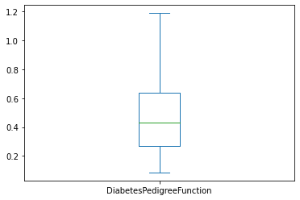

```python
# Diabetes Pedigree Function

# Remove outliers from DiabetesPedigreeFunction feature
diabetes_pedigree_outlier = diabetes["DiabetesPedigreeFunction"] < 1.2

diabetes = diabetes[diabetes_pedigree_outlier]

# Vusal inspection
diabetes["DiabetesPedigreeFunction"].plot(kind="box");
```

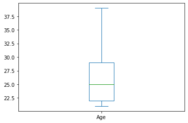

```python
# Age

# Remove outliers in age feature
age_outlier = diabetes["Age"] < 40
diabetes = diabetes[age_outlier]

# Visual inspection
diabetes["Age"].plot(kind="box");
```

## Bivariate Exploration

```python
def violin_plot(x, y):
    sns.violinplot(x, y);
```

### Q10. What is the relationship between number of pregnancies and outcome of diabetes?

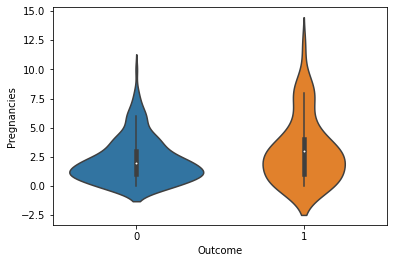

```python
# Bivariate plot of Pregnancy and Outcome
violin_plot(diabetes["Outcome"], diabetes["Pregnancies"])
```

**Observation**: Participants with diabetes on average gave more number of pregnancies compared to participants without diabetes. Majority of participants without diabetes have less than 3 pregnancies.

### Q11.What is the relationship between serum glucose and diabetes?

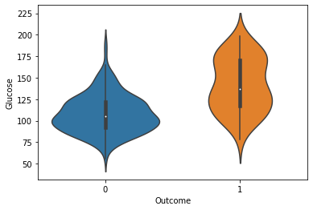

```python
# Bivariate plot of Outcome vs Glucose
violin_plot(diabetes["Outcome"], diabetes["Glucose"]);
```

**Observation**: Serum glucose measurement were higher on average in participants with diabetes compared to participants without diabetes.

### Q12. What is the relationship between blood pressure measurement and diabetes?

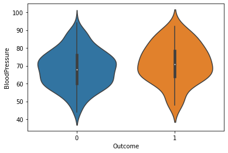

```python
# Bivariate plot of Outcome vs BloodPressure
violin_plot(diabetes["Outcome"], diabetes["BloodPressure"]);
```

**Observation**: Participants with diabetes have higher blood pressure readings on average compared to participants without diabetes.

### Q13. What is the relationship between triceps skinfold thickness and diabetes?

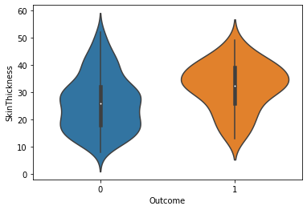

```python
# Bivariate plot of Outcome vs SkinThickness
violin_plot(diabetes["Outcome"], diabetes["SkinThickness"]);
```

**Observation**: Participants with diabetes have higher triceps skinfold thickness compared to participants without diabetes.

### Q14. What is the relationship between insulin and diabetes?

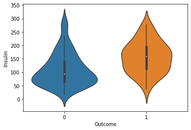

```python
# Bivariate plot of Outcome vs Insulin
violin_plot(diabetes["Outcome"], diabetes["Insulin"]);
```

**Observation**: Average insulin measured in participants with diabetes was higher on average compared to participants without diabetes.

### Q15. What is the relationship between BMI and diabetes?

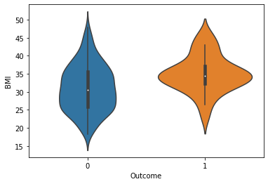

```python
# Bivariate plot of Outcome vs BMI
violin_plot(diabetes["Outcome"], diabetes["BMI"]);
```

**Observation**: Participants with diabetes have higher BMI on average compared to participants without diabetes.

### Q16. What is the relationship between diabetes pedigree function and diabetes?

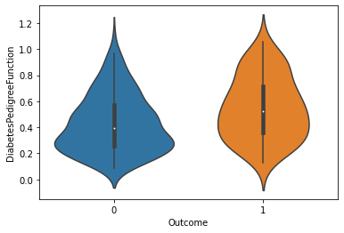

```python
# Bivariate plot of Outcome vs DiabetesPedigreeFunction
violin_plot(diabetes["Outcome"], diabetes["DiabetesPedigreeFunction"]);
```

**Observation**: Particpants with diabetes have a higher diabetes pedigree function on average compared to particpants without diabetes.

### Q17. What is the relationship between age and diabetes?

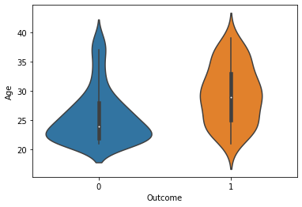

```python
# Bivariate plot of Outcome vs Age
violin_plot(diabetes["Outcome"], diabetes["Age"]);
```

**Observation**: Participants with diabetes are older on average compared to participants without diabetes.

### Q18. What is the relationship betweeen numeric features in the dataset?

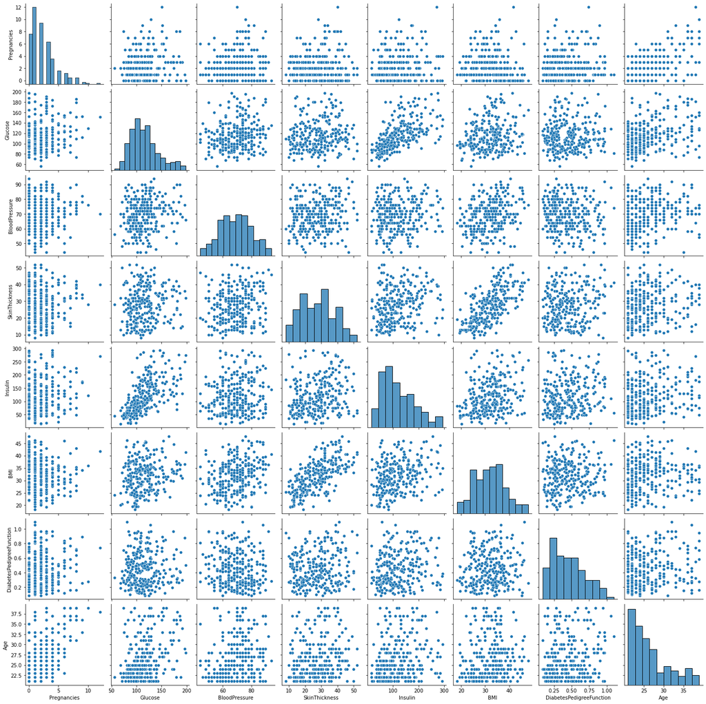

```python
# Drop outcome feature from copy dataset
diabetes_scatter = diabetes.copy()


diabetes_scatter.drop(["Outcome"], axis = 1, inplace = True)

# Scatter plot matrix
sns.pairplot(diabetes_scatter, dropna = True);
```

**Observation**: There is a strong correlation between BMI and triceps skinfold thickness as well as between insulin and glucose. These will be investigated further in the next step.

### Talk about some of the relationships you observed in this part of the investigation. How did the feature(s) of interest vary with other features in the dataset?

Diabetes is associated with age, number of pregnancies, blood pressure, triceps skinfold thickness, serum insulin measurement, BMI, and Diabetes Pedigree Function. Participants with diabetes were older compared to participants without diabetes. Participants with diabetes had higher values for number of pregnancies, blood pressure, triceps skinfold, serum insulin measurement, serum glucose, BMI and Diabetes pedigree function on average compared to participants without diabetes.

### Did you observe any interesting relationships between the other features (not the main feature(s) of interest)?

BMI and Triceps skinfold thickness had a strong correlation as well as the serum glucose and insulin.

## Multivariate Exploration

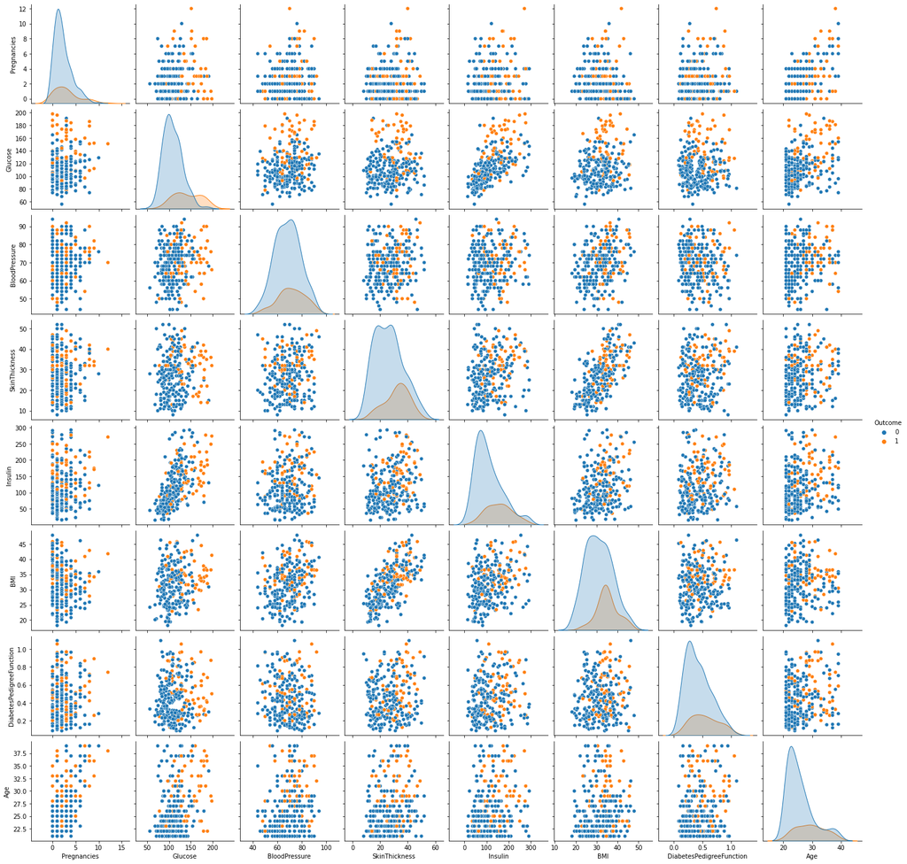

```python
# Scatter plot matrix
sns.pairplot(diabetes, dropna = True, hue = "Outcome");
```

### Talk about some of the relationships you observed in this part of the investigation. Were there features that strengthened each other in terms of looking at your feature(s) of interest?

Participants with diabetes clearly had higher serum glucose levels and insulin levels. As expected, when serum glucose increases which may lead to a diagnosis of diabetes, endogenous insulin production also tend to increase.

### Were there any interesting or surprising interactions between features?

Participants with higher BMI and higher triceps skinfold had some participants with and without diabetes. The relationship between triceps skinfold and BMI stratified by diabetes is not clear enough to warrant the significant association between diabetes, BMI and triceps skinfold.

## Conclusions

Univariate exploration was used to create visualisation for single features to investigate distributions as well as frequency counts. Bivariate exploration was used to create visualisation to investigation the relationship between two features. Then, multivariate exploration was used to explore the relation between more than two features. All in all, diabetes as an outcome of interest was associated with age, number of pregnancies, blood pressure, triceps skinfold thickness, serum insulin measurement, BMI, and Diabetes Pedigree Function. Participants with diabetes were on average older than participants without diabetes. The chances of diabetes increased with increasing number of pregnancies, blood pressure, triceps skinfold thinckness and BMI. Participants with diabetes had higher amounts of serum insulin compared to participants without diabetes and a higher Diabetes Pedigree Funtion on average was also associated with increased chances of having diabetes.